# Week 10 Discussion :)

Natalie Gabra

2026-03-09

#Q1

Is there a relationship between favorite color and preferred shape?

```r
library("tidyverse")
library("dplyr")
```

```r
classdata <- read.csv("classdata.csv")
```

```r
color_shape <- classdata %>%
  group_by(fave_color, shape) %>%
  summarise(count = n(), .groups = "drop")

color_shape <- color_shape %>%
  mutate(fave_color = fct_reorder(fave_color, count))
```

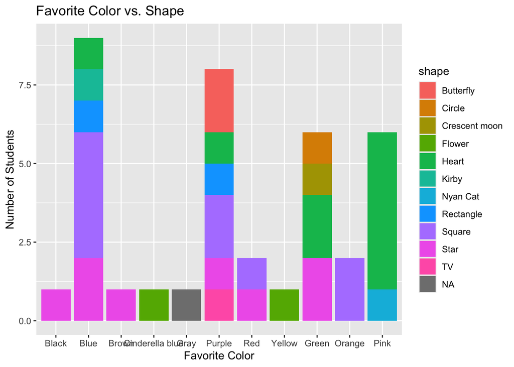

```r
ggplot(color_shape, aes(x = fave_color, y = count, fill = shape)) +
  geom_col() +
  labs(
    title = "Favorite Color vs. Shape",
    x = "Favorite Color",
    y = "Number of Students")
```

The plot shows that certain colors are often chosen with a preferred shape, but more analysis needs to be done to see if there is a significant relationship.

#Q2 The most memorable thing from discussion was the week we spoke about AI use and its effects on us as humans! Thinking about how it has the ability to take away our gift of creativity, critical thinking, and the things that are related to our rationality is scary.

#Q3 I learned to pursue truth and to really consider what I want to be in the world and give to the world. I’d like to exercise the different faculties of my mind and learn new skills. I would like to become a beautiful human being filled with virtue! :)

#Q4 Yes I do! My dream was to have a farm and I am very determined to make it happen one step at a time.

#Q5 Thank youuuu so much Brittney for being you and your teaching style. Your presence is very joyful and full of light. And I love that you always emphasized there is more to what makes us human that is not our career or education or anything else.